# R Notebook

```r
library(factoextra)
```

```r
library(cluster)
```

# load and scale the dataset

```r
#load data
df <- USArrests

df <- na.omit(df)

#scale each variable to have a mean of 0 and sd of 1
df <- scale(df)

#view first six rows of dataset
head(df)
```

|  | Murder | Assault | UrbanPop | Rape |
| --- | --- | --- | --- | --- |
| Alabama | 1.24256408 | 0.7828393 | -0.5209066 | -0.003416473 |
| Alaska | 0.50786248 | 1.1068225 | -1.2117642 | 2.484202941 |
| Arizona | 0.07163341 | 1.4788032 | 0.9989801 | 1.042878388 |
| Arkansas | 0.23234938 | 0.2308680 | -1.0735927 | -0.184916602 |
| California | 0.27826823 | 1.2628144 | 1.7589234 | 2.067820292 |
| Colorado | 0.02571456 | 0.3988593 | 0.8608085 | 1.864967207 |

# Find the Linkage Method to Use

```r
#define linkage methods
m <- c( "average", "single", "complete", "ward")
names(m) <- c( "average", "single", "complete", "ward")

#function to compute agglomerative coefficient
ac <- function(x) {
  agnes(df, method = x)$ac
}

#calculate agglomerative coefficient for each clustering linkage method
sapply(m, ac)
```

```
  average    single  complete      ward
0.7379371 0.6276128 0.8531583 0.9346210
```

We can see that Ward’s minimum variance method produces the highest agglomerative coefficient, thus we’ll use that as the method for our final hierarchical clustering:

# Build the final hierarchical clustering

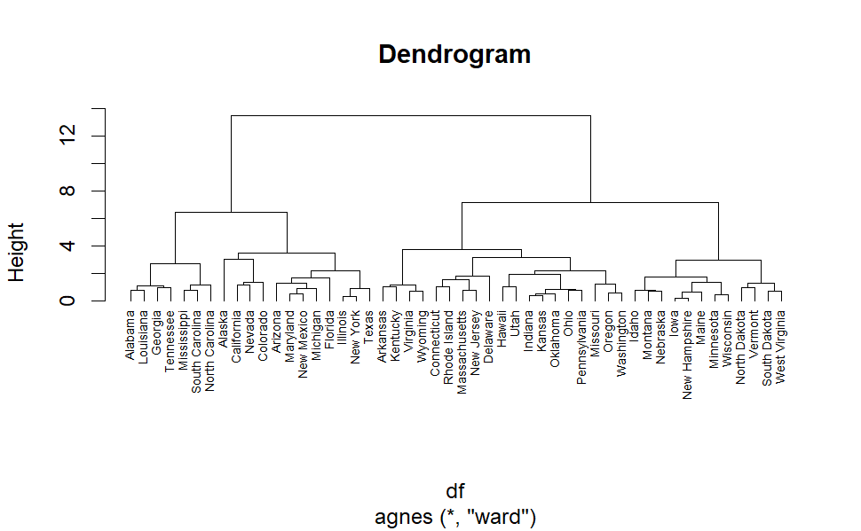

```r
#perform hierarchical clustering using Ward's minimum variance
clust <- agnes(df, method = "ward")

#produce dendrogram
pltree(clust, cex = 0.6, hang = -1, main = "Dendrogram")
```

# Determine the Optimal Number of Clusters

## Gap stat

https://hastie.su.domains/Papers/gap.pdf

## mise en oeuvre

```r
#calculate gap statistic for each number of clusters (up to 10 clusters)
gap_stat <- clusGap(df, FUN = hcut, nstart = 25, K.max = 10, B = 50)
```

```
Clustering k = 1,2,..., K.max (= 10): .. done
Bootstrapping, b = 1,2,..., B (= )  [one "." per sample]:
.................................................. 50
```

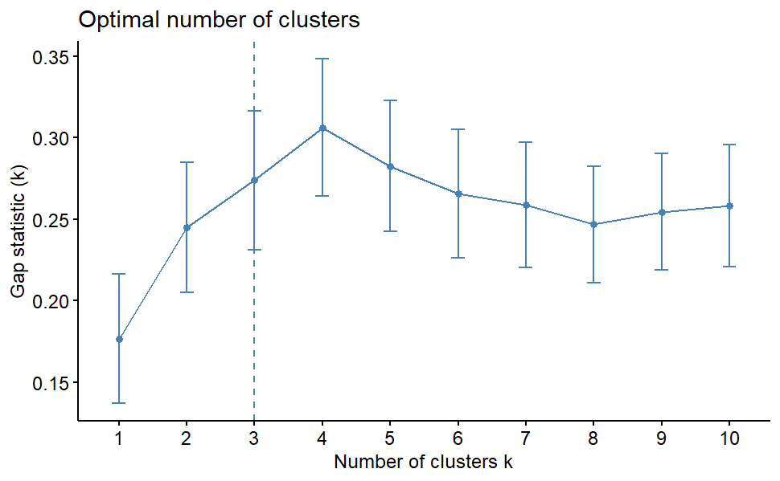

```r
#produce plot of clusters vs. gap statistic
fviz_gap_stat(gap_stat)
```

From the plot we can see that the gap statistic is highest at k = 4 clusters. Thus, we’ll choose to group our observations into 4 distinct clusters.

# Cluster Labels to Original Dataset : hclust()

```r
#compute distance matrix
d <- dist(df, method = "euclidean")

final_clust <- hclust(d, method = "ward.D2" )

#cut the dendrogram into 4 clusters
groups <- cutree(final_clust, k=4)

#find number of observations in each cluster
table(groups)
```

```
groups
 1  2  3  4
 7 12 19 12
```

We can then append the cluster labels of each state back to the original dataset:

```r
#append cluster labels to original data
final_data <- cbind(USArrests, cluster = groups)

#display first six rows of final data
head(final_data)
```

|  | Murder | Assault | UrbanPop | Rape | cluster |
| --- | --- | --- | --- | --- | --- |
| Alabama | 13.2 | 236 | 58 | 21.2 | 1 |
| Alaska | 10.0 | 263 | 48 | 44.5 | 2 |
| Arizona | 8.1 | 294 | 80 | 31.0 | 2 |
| Arkansas | 8.8 | 190 | 50 | 19.5 | 3 |
| California | 9.0 | 276 | 91 | 40.6 | 2 |
| Colorado | 7.9 | 204 | 78 | 38.7 | 2 |

Lastly, we can use the **aggregate()** function to find the mean of the variables in each cluster:

```r
#find mean values for each cluster
aggregate(final_data, by=list(cluster=final_data$cluster), mean)
```

| cluster | Murder | Assault | UrbanPop | Rape | cluster |
| --- | --- | --- | --- | --- | --- |
| 1 | 14.671429 | 251.2857 | 54.28571 | 21.68571 | 1 |
| 2 | 10.966667 | 264.0000 | 76.50000 | 33.60833 | 2 |
| 3 | 6.210526 | 142.0526 | 71.26316 | 19.18421 | 3 |
| 4 | 3.091667 | 76.0000 | 52.08333 | 11.83333 | 4 |

We interpret this output is as follows:

- The mean number of murders per 100,000 citizens among the states in cluster 1 is **14.67**.
- The mean number of assaults per 100,000 citizens among the states in cluster 1 is **251.28**.
- The mean percentage of residents living in an urban area among the states in cluster 1 is **54.28%**.
- The mean number of rapes per 100,000 citizens among the states in cluster 1 is **21.68**.

# Color the cluster

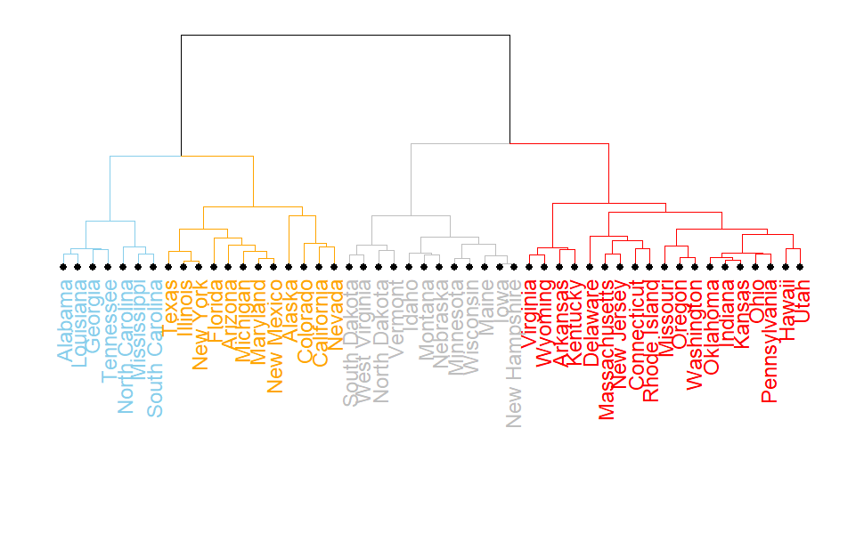

```r
# Create a vector of colors, darkgreen if am is 0, green if 1.
my_colors <- ifelse(mtcars$am==0, "forestgreen", "green")


dend = as.dendrogram(final_clust)

# Make the dendrogram
par(mar=c(10,1,1,1))
dend %>%
  set("labels_col", value = c("skyblue", "orange", "grey","red"), k=4) %>%
  set("branches_k_color", value = c("skyblue", "orange", "grey", "red"), k = 4) %>%
  set("leaves_pch", 19)  %>%
  set("nodes_cex", 0.7) %>%
  plot(axes=FALSE)
```

# clustering with HCPC

```r
library(FactoMineR)
# 1. ACP
res.pca <- PCA(df, ncp = 3,graph = FALSE)
# 2. HCPC
res.hcpc <- HCPC(res.pca,
                 nb.clust = 4,
                 metric = "euclidean",
                 method = "ward",
                 graph = FALSE)
```

```r
#find number of observations in each cluster
table(res.hcpc$data.clust[,5])
```

```
 1  2  3  4
13 16  8 13
```

```r
#append cluster labels to original data
data_hcpc <- cbind(USArrests, cluster = res.hcpc$data.clust[,5])

#display first six rows of final data
head(data_hcpc)
```

|  | Murder | Assault | UrbanPop | Rape | cluster |
| --- | --- | --- | --- | --- | --- |
| Alabama | 13.2 | 236 | 58 | 21.2 | 3 |
| Alaska | 10.0 | 263 | 48 | 44.5 | 4 |
| Arizona | 8.1 | 294 | 80 | 31.0 | 4 |
| Arkansas | 8.8 | 190 | 50 | 19.5 | 3 |
| California | 9.0 | 276 | 91 | 40.6 | 4 |
| Colorado | 7.9 | 204 | 78 | 38.7 | 4 |

```r
#find mean values for each cluster
aggregate(data_hcpc, by=list(cluster=data_hcpc$cluster), mean)
```

| cluster | Murder | Assault | UrbanPop | Rape | cluster |
| --- | --- | --- | --- | --- | --- |
| 1 | 3.60000 | 78.53846 | 52.07692 | 12.17692 | NA |
| 2 | 5.65625 | 138.87500 | 73.87500 | 18.78125 | NA |
| 3 | 13.93750 | 243.62500 | 53.75000 | 21.41250 | NA |
| 4 | 10.81538 | 257.38462 | 76.00000 | 33.19231 | NA |

## Dendrogram with clusters

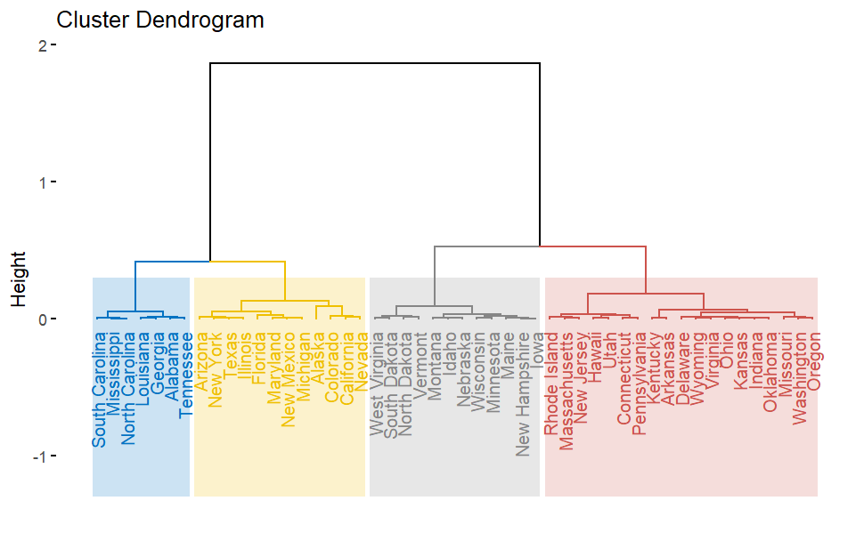

```r
fviz_dend(res.hcpc,
          cex = 0.7,                     # Taille du text
          palette = "jco",               # Palette de couleur ?ggpubr::ggpar
          rect = TRUE, rect_fill = TRUE, # Rectangle autour des groupes
          rect_border = "jco",           # Couleur du rectangle
          labels_track_height = 0.8      # Augment l'espace pour le texte
          )
```

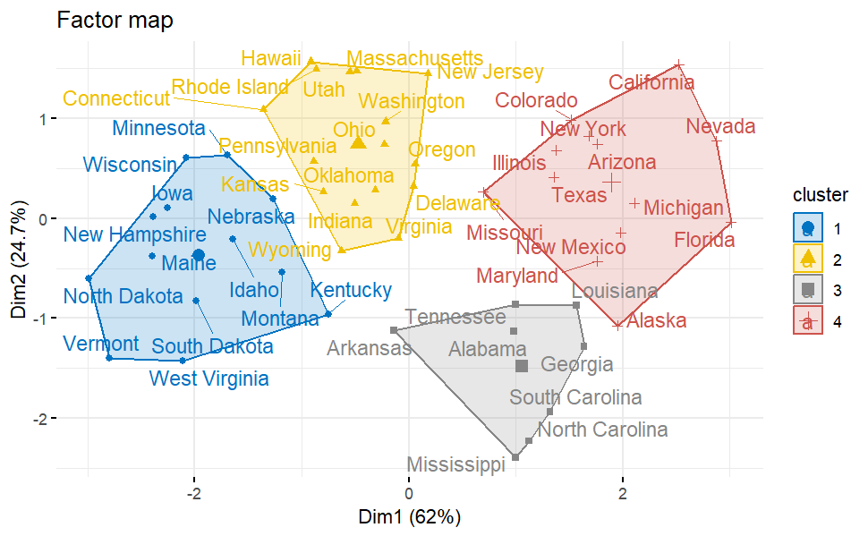

```r
fviz_cluster(res.hcpc,
             repel = TRUE,            # Evite le chevauchement des textes
             show.clust.cent = TRUE, # Montre le centre des clusters
             palette = "jco",         # Palette de couleurs, voir ?ggpubr::ggpar
             ggtheme = theme_minimal(),
             main = "Factor map"
             )
```